# Module 2: Data Collection Protocols & Sampling Design

Somali Fish Stock Training

Dr. Masumbuko Semba

lugosemba@gmail.com

Nelson Mandela African Institution of Science and Technology

Dr. Rushingisha George

george.rushingisha@tafiri.go.tz

Tangania Fisheries Research Institute

Dr. Mary Kishe

mary.kishe@tafiri.go.tz

Tanzania Fisheries Research Institute

Dr. Ismael Kimirei

ismael.kimirei@tafiri.go.tz

Tanzania Fisheries Research Institute

2025-12-05

## Welcome to Module 2

**Data Collection Protocols & Sampling Design**

### Learning Objectives

- Design effective sampling schemes
- Understand quality control procedures
- Master catch/effort data handling
- Implement data validation protocols

### Why This Matters

- **High-priority area** from needs assessment
- Addresses key implementation gaps
- Directly improves data quality
- Supports sustainable monitoring

## The Data Quality Foundation

### Why Data Collection Matters:

- Poor data → poor decisions
- Good protocols → reliable assessments
- Consistent methods → comparable results
- Quality control → confidence in findings

### Module 2 Focus:

Practical, implementable protocols for Somali context

## Core Sampling Principles

**1. Representativeness** - Sample reflects population - Avoid biased selection - Random or stratified approach

**2. Consistency** - Same methods over time - Standardized procedures - Documented protocols

**3. Adequacy** - Sufficient sample size - Temporal coverage - Spatial distribution

**4. Independence** - Samples unrelated to each other - Avoid pseudo-replication - Account for dependencies

## Sampling Design Types

### Stratified Sampling Strategy

Divide population into strata, sample from each:

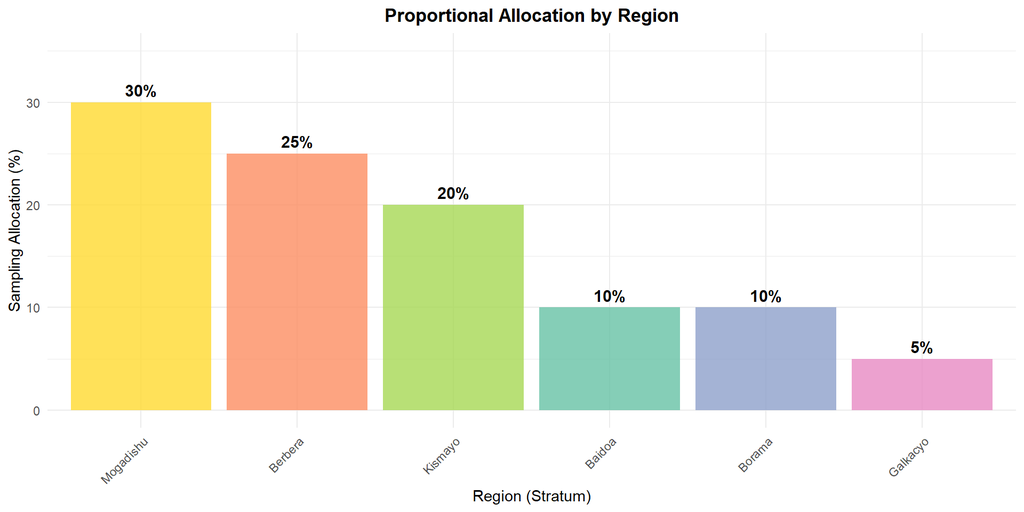

## Sampling Approaches for Somalia

### Option 1: Census Sampling

**Sample every landing during monitoring period**

**Advantages:** - ✓ No missing data - ✓ Highest precision - ✓ Detect all changes

**Challenges:** - ✗ High cost - ✗ Requires many staff - ✗ Logistically difficult

## Sampling Approaches (continued)

### Option 2: Systematic Sampling

**Sample every nth landing (e.g., every 5th fish)**

**Advantages:** - ✓ Balanced coverage - ✓ Practical to implement - ✓ Moderate cost

**Challenges:** - ✗ May miss patterns - ✗ Requires discipline - ✗ Vulnerable to bias

## Sampling Approaches (continued)

### Option 3: Random Sampling

**Randomly select landings to measure**

**Advantages:** - ✓ Statistically sound - ✓ Unbiased - ✓ Defensible method

**Challenges:** - ✗ Gaps in coverage - ✗ Lower precision - ✗ Requires planning

## Recommended Protocol for Somalia

### Stratified-Systematic Approach:

1. **Stratify by region** (6 regions: Berbera, Mogadishu, etc.)
2. **Allocate proportionally** to landing volumes
3. **Sample systematically** within each region
4. **Monthly rotations** at sites to avoid bias
5. **Document everything** for quality control

## Catch Data Collection

### What to Record:

**Essential Variables** - [ ] Date and time - [ ] Landing site/location - [ ] Vessel/fisher ID - [ ] Species/fish group - [ ] Total catch (count) - [ ] Total weight

**Biological Data** - [ ] Individual lengths - [ ] Individual weights - [ ] Sex (if identifiable) - [ ] Maturity stage - [ ] Condition assessment

## Catch Data Form Example

Standardized Catch Data Form

Fields and requirements for field collection

| Data Field | Data Type | Required? | Example Value |
| --- | --- | --- | --- |
| Landing_Date | Date (YYYY-MM-DD) | Yes | 2024-01-15 |
| Region | Text | Yes | Berbera |
| Landing_Site | Text | Yes | Port_North |
| Fish_Group | Dropdown | Yes | Tuna |
| Sample_ID | Numeric | Yes | BER_001 |
| Length_cm | Numeric | Yes | 45.2 |
| Weight_kg | Numeric | Yes | 12.5 |
| Notes | Text | No | Good condition |

## Effort Data Collection

### What Constitutes “Effort”?

- **Fishing effort**: Days fished, hours at sea, gear type
- **Landing site effort**: Number of vessels arriving
- **Spatial effort**: Geographic distribution of fishing
- **Temporal effort**: Daily, monthly, seasonal patterns

### Why Effort Matters:

To calculate CPUE, we need **both catch AND effort**

## Effort Data: Practical Implementation

### Daily Log Sheet:

Daily Landing Site Effort Log

Example from field monitoring

| Date | Region | Vessels_Arrived | Total_Landings | Staff_Available | Sampling_Rate_% |
| --- | --- | --- | --- | --- | --- |
| 2024-01-15 | Berbera | 12 | 450 | 3 | 100 |
| 2024-01-15 | Berbera | 5 | 280 | 2 | 50 |
| 2024-01-16 | Mogadishu | 18 | 520 | 4 | 75 |
| 2024-01-16 | Mogadishu | 22 | 680 | 3 | 50 |

## Quality Control Procedures

### Five-Step QC Protocol:

**1. Training & Standardization** - Clear protocols - Hands-on training - Refresher sessions - Competency testing

**2. Real-Time Checks** - Verify as collecting - Cross-checks with partners - Outlier flagging

**3. Data Entry Validation** - Range checks - Logical consistency - Missing value detection - Double-entry verification

**4. Statistical Review** - Distribution analysis - Trend assessment - Comparison with history

## Quality Control (continued)

### Step 5: Documentation

**Important**

**Every data point needs metadata:** - Who collected it? - When and where? - Under what conditions? - Any uncertainties? - Contact for questions?

## Common Data Quality Issues

### Watch for These Problems:

**Measurement Errors** - Improper length measurement - Scale calibration issues - Rounding inconsistencies - Unit confusion (cm vs mm)

**Procedural Errors** - Skipped fish - Incomplete recording - Wrong species ID - Timestamp mistakes

**Data Entry Errors** - Transcription mistakes - Transposed numbers - Missing data codes - Format inconsistencies

**Sampling Bias** - Selective sampling - Non-random selection - Temporal gaps - Geographic avoidance

## Data Entry Best Practices

### Digital Form Design:

- **Dropdown menus** for categories (Region, Species)
- **Numeric validation** (length > 0, weight > 0)
- **Date pickers** for temporal data
- **GPS integration** for location accuracy
- **Offline capability** for field areas
- **Sync protocols** for data backup

### Recommended Tools:

- ODK Collect (mobile)
- Kobo Toolbox (cloud-based)
- Excel with data validation
- R/Shiny for real-time dashboards

## Catch/Effort Data Handling

### Processing Workflow:

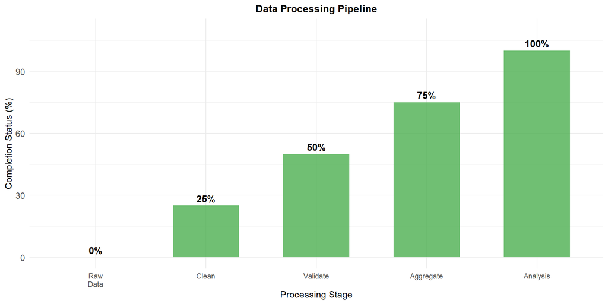

## Data Cleaning in R

### Essential Steps:

```r
# 1. Remove duplicates
data_clean <- data_raw |>
  distinct()

# 2. Validate ranges
data_clean <- data_clean |>
  filter(length_cm > 5 & length_cm < 200,
         weight_kg > 0.1 & weight_kg < 500)

# 3. Handle missing values
data_clean <- data_clean |>
  filter(!is.na(species), !is.na(length_cm))

# 4. Standardize formats
data_clean <- data_clean |>
  mutate(
    landing_date = as.Date(landing_date),
    region = toupper(region)
  )
```

## Data Aggregation Examples

### Catch by Species & Region:

```r
catch_summary <- data |>
  filter(!is.na(species), !is.na(region)) |>
  group_by(year, region, species) |>
  summarise(
    total_catch = n(),
    mean_length = mean(length_cm, na.rm = TRUE),
    .groups = 'drop'
  )
```

### CPUE Calculation:

```r
cpue_data <- catch_effort |>
  group_by(year, region) |>
  summarise(
    total_catch = sum(catch),
    effort = sum(fishing_days),
    cpue = total_catch / effort,
    .groups = 'drop'
  )
```

## Documentation Requirements

### Every Data Collection Needs:

**Note**

**Collection Protocol Document** should include: - Purpose and objectives - Sampling design details - Variable definitions - Measurement procedures - Quality standards - Staff responsibilities - Error handling procedures - Data storage and backup - Troubleshooting guide

## Somali Implementation Strategy

### Realistic Roadmap:

**Phase 1 (Months 1-2):** - Train 2-3 coordinators per site - Develop standardized forms - Set up data entry system - Pilot testing at 2 sites

**Phase 2 (Months 3-6):** - Roll out to all 6 regions - Monthly data reviews - Troubleshoot issues - Refine procedures

**Phase 3 (Months 7+):** - Full implementation - Ongoing QC checks - Capacity building - Data analysis & reporting

## Common Challenges & Solutions

### Challenge: Limited Resources

**Solutions:** - Prioritize core variables - Use volunteers/assistants - Mobile phone apps - Digital sampling tools

### Challenge: Geographic Dispersal

**Solutions:** - Hub-and-spoke model - Regional coordinators - Periodic site visits - Remote monitoring support

## Common Challenges (continued)

### Challenge: Staff Turnover

**Solutions:** - Document all procedures - Regular training refreshers - Competency assessments - Mentorship programs

### Challenge: Inconsistent Participation

**Solutions:** - Financial incentives - Community engagement - Clear schedules - Regular feedback

## Data Management Best Practices

### Storage & Security:

**Local Storage** - Backup hard drives - Cloud backup (OneDrive) - Encrypted storage - Access controls

**Data Access** - Version control - Change logs - User permissions - Audit trails

### Retention Policy:

- Keep raw data forever
- Archive processed data
- Document metadata
- Establish data governance

## Key Takeaways

### Module 2 Summary:

1. Sampling design must match objectives & resources
2. Data quality requires protocols, training, and oversight
3. Catch AND effort data essential for CPUE
4. Quality control built in from collection through analysis
5. Digital tools improve consistency and efficiency
6. Documentation critical for sustainability
7. Implementation must be realistic for Somalia context

## Transition to Module 3

### You Now Have:

- ✓ **Module 1**: Conceptual foundation
- ✓ **Module 2**: Operational protocols
- **Module 3**: Data-limited assessment methods (coming next)

### Next Session:

Using the data collected through Module 2 protocols to conduct stock assessments with R!

## Practical Homework

### Before Module 3:

**Note**

1. **Design** a sampling protocol for your region
2. **Create** a data entry form
3. **Plan** quality control checks
4. **Identify** implementation challenges
5. **Prepare** questions for Module 3

### Deliverable:

One-page sampling plan for your region

## References & Resources

### Sampling Design:

- FAO: Guidelines for data collection
- IOTC Data collection procedures
- Cochran (1977): Sampling techniques

### Quality Control:

- ISO 17025 standards
- NOAA Data management guidelines
- WHO Data quality framework

### R Resources:

- RMarkdown for documentation
- Data validation packages
- CPUE analysis functions

## Questions & Discussion

### Let’s Discuss:

- What challenges do you foresee?
- How would you adapt protocols locally?
- What resources are available?
- How often can you monitor?
- Who will coordinate data?

## Thank You

**Somali Fish Stock Training**

Module 2: Data Collection Protocols & Sampling Design

*Implementing practical, sustainable monitoring*

Next: Module 3 - Data-Limited Assessment Methods

Questions? Contact the training team.